# Lecture 25: Cryptography and the Law

### Announcements

- Please pick up your card
- Please complete the course survey form (if you have not already done so)
- Due today at 6pm on Gradescope:
  - Homework 10
  - Test 3 retries
- Final exam is on Friday 12/19 at 9-11am in the lecture room (EPC 207)
  - 4 points on each of Units 1, 2, 3
  - 6 points on Unit 4
  - Has selection and free-response questions

### Learning outcomes

By the end of today’s lecture, you will learn:

- Where and why the law might require, incentivize, constrain, or prohibit the use of cryptography
- Your rights and responsibilities to use your cryptographic knowledge for good

### Overview

The goals of this course are to teach you:

- How to think from an adversarial perspective
- Where we can use cryptography to build secure and trustworthy data science systems

It turns out that (some) lawyers think about these topics too! In this final lecture, we will discuss the relationship between cryptography and the law.

Some ground rules upfront:

- I will ask you questions today, but they generally have no “right” or “wrong” answers… so please share your genuine opinions!
- Relatedly: I encourage discussion and debate on ideas, but do *not* criticize other people

Important caveats:

- We will focus today on the law in the United States… and only some of them, at a high level
- I am not a lawyer, and this lecture is not legal advice!
- If you ever do need free legal advice about technology, all BU students can visit the [BU/MIT Student Innovations Law Clinic](https://www.bu.edu/law/experiential-learning/clinics/bu-mit-student-innovations-law-clinic/)

[figure not shown]

I want to credit [Andy Sellars](https://www.albertsellars.law/team), former BU professor and director of the BU/MIT law clinic, as the inspiration for many of the topics that I will present today.

I have structured today’s lecture around parts of the U.S. Constitution. As a result:

- I will mostly focus on the relationship between government and individual people, and the rights and freedoms that people have
- I will say less about regulations imposed by the government on technology companies

## 25.1 Crypto and the First Amendment

The First Amendment to the U.S. Constitution says (emphasis added by me):

> Congress shall make no law respecting an establishment of religion, or prohibiting the free exercise thereof; or abridging the **freedom of speech**, or of the press; or the right of the people peaceably to assemble, and to petition the Government for a redress of grievances.

**Interactive question.** Where do you think that cryptography most often connects to freedom of speech?

1. Users of cryptography argue that using cryptography is free speech
2. Users of cryptocurrency argue that posting monetary transactions on a blockchain is free speech
3. Developers of cryptocurrency smart contracts argue that distributing crypto is free speech
4. Developers of cryptography code argue that releasing open-source code is free speech

*Answer*. The first three arguments have been debated in [law journals](https://repository.law.uic.edu/jitpl/vol14/iss2/6/), [web posts](https://finance.yahoo.com/news/why-bitcoin-protected-first-amendment-131705071.html), and [court cases](https://decrypt.co/283890/tornado-cash-roman-storm-free-speech-defense). In today’s lecture, I want to focus on item D.

### Crypto wars

“*Crypto wars*” is an informal, and bombastic, term to describe the long-running debate between:

- Civil libertarians who (to oversimplify) believe that encryption can shield potential victims and therefore *protect public safety*
- Government law enforcement and national security officials who (again to oversimplify) believe that they need to decrypt data in order to find dangerous people and *protect public safety*

I like to think about the “crypto wars” as proceeding in three phases.

1. **Key length**: governments try to limit the length of cryptographic key material, in order to make brute force attacks easier
2. **Key escrow**: governments try to build devices that send a copy of the cryptographic key to them
3. **Key ephemerality**: governments try to stop end-to-end encryption and one-time use keys, instead preferring client-server encryption with long-term keys that they can fetch from the server

### Restricting key length

In the 1970s, the government directly tried to limit key length through its standardization power.

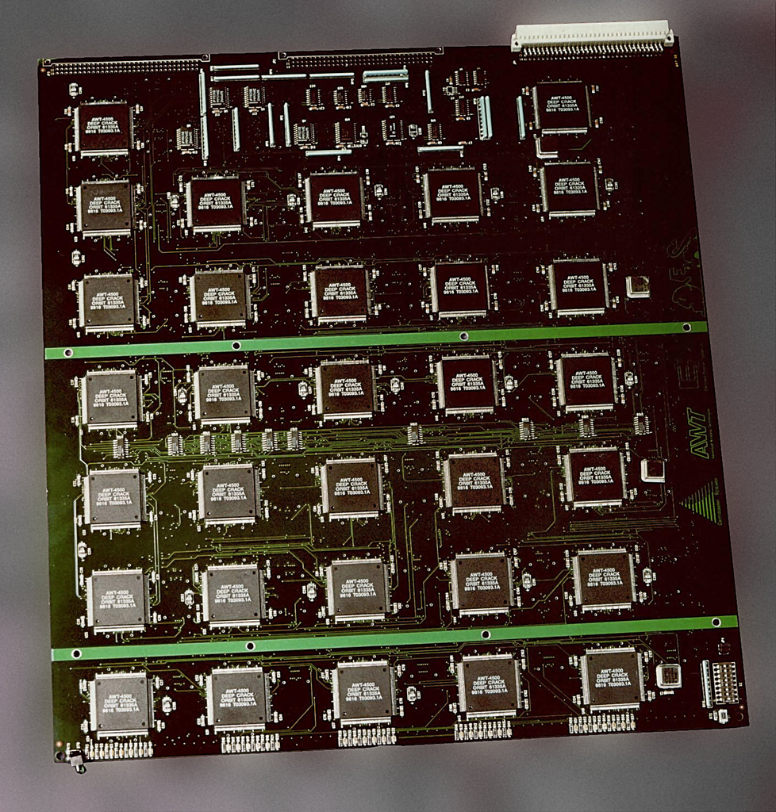

EFF’s DES cracking machine (image source: [Wikipedia](https://en.wikipedia.org/wiki/Data_Encryption_Standard))

By the 1990s, the U.S. government tried to restrict key length via *export controls*. People inside the United States could download software with strong key lengths, but everyone else could only use 40-bit keys.

Cryptographers came up with many clever (and sometimes useful) ways to circumvent the spirit – but not the letter – of export control restriction on computer code.

[figure not shown]

Image source: [Wikipedia](https://en.wikipedia.org/wiki/Code_as_speech)

[figure not shown]

Image source: [Amazon](https://www.amazon.com/Applied-Cryptography-Protocols-Algorithms-Source/dp/0471117099)

### Code as speech

How does the First Amendment relate to restrictions on key length? Let’s discuss the court case *Bernstein v. United States*.

- In the 1990s, Dan Bernstein was a PhD student at UC Berkeley, and then a professor at UIC
- With the assistance of lawyers from the [Electronic Frontier Foundation](https://www.eff.org/), he sued the U.S. government to argue against a then-requirement to pre-register his crypto code with the government and obtain a license to distribute it
- He won! The U.S. appeals court in northern California decided that “the challenged regulations constitute a prior restraint on speech that offends the First Amendment” ([source](https://www.eff.org/files/filenode/bernstein/19990506_circuit_decision.html)).

This court decision (and a few others) form part of a [legal argument](https://en.wikipedia.org/wiki/Code_as_speech) in the United States that creating and disseminating computer code is an act of expression that can constitute legally-protected speech.

Apple cited the *Bernstein* case in its arguments for the 2016 *Apple v. FBI* court case that we discussed in Lecture 15.

Do not take this “code as speech” argument too literally. If you do illegal things with computers, do **not** expect this to act as a get-out-of-jail free card.

## 25.2 Crypto and the Second and Third Amendments?

The Second Amendment to the U.S. Constitution says:

> A well regulated Militia, being necessary to the security of a free State, the right of the people to keep and bear Arms, shall not be infringed.

The Third Amendment to the U.S. Constitution says:

> No Soldier shall, in time of peace be quartered in any house, without the consent of the Owner, nor in time of war, but in a manner to be prescribed by law.

The Third Amendment is rarely relevant to anything.

[figure not shown]

Image source: [The Onion](https://theonion.com/third-amendment-rights-group-celebrates-another-success-1819569379/)

I suppose it is [possible](https://repository.uclawsf.edu/cgi/viewcontent.cgi?article=1001&context=hastings_science_technology_law_journal) to [connect](https://bitcoinmagazine.com/legal/digital-second-amendment-preserving-bitcoin-rights) these amendments to crypto.

[figure not shown]

Admittedly these arguments are a stretch, and these amendments do not directly impact crypto as much as the First Amendment did. But still:

- What is the Clipper chip?
- Should cryptography be categorized as a *weapon*, for legal purposes? (Remember that militaries have been using cryptography for thousands of years, going back to Julius Caesar.)

### Clipper chip

The second crypto war, in the 1990s, was focused on **key escrow**, in which governments tried to build devices that would copy cryptographic keys and send a copy to themselves.

[figure not shown]

Clipper chip (image source: [Wikipedia](https://en.wikipedia.org/wiki/Clipper_chip))

Probably the most famous example of key escrow was the U.S. National Security Agency’s failed attempt to install a *Clipper chip* on every telephone, which would “allow Federal, State, and local law enforcement officials the ability to decode intercepted voice and data transmissions.”

[figure not shown]

Anti-Clipper chip advertisement

One of the reasons the Clipper chip idea failed is that it could not withstand cryptanalysis.

- In 1994, Matt Blaze published a [paper](https://dl.acm.org/doi/10.1145/191177.191193) showing how to circumvent the Clipper chip
- In the late 1990s, cryptographers showed a variety of [instrinsic risks](https://dspace.mit.edu/handle/1721.1/117329) and [fundamental flaws](https://dl.acm.org/doi/10.1145/227234.227239) in all proposed key escrow algorithms

### Funding of crypto research

We also see the dichotomy between civilian and military applications of crypto when looking at funding sources for crypto research.

In the early 1980s, the U.S. government commissioned a report to consider the best organization to oversee and fund research in cryptography.

- [NSF](https://www.nsf.gov/) supports basic science research broadly
- [NSA](https://www.nsa.gov/) and [DARPA](https://www.darpa.mil/) support research with applications to the Department of Defense

Generally, the report recommends all of the above. These agencies all support crypto research to this day.

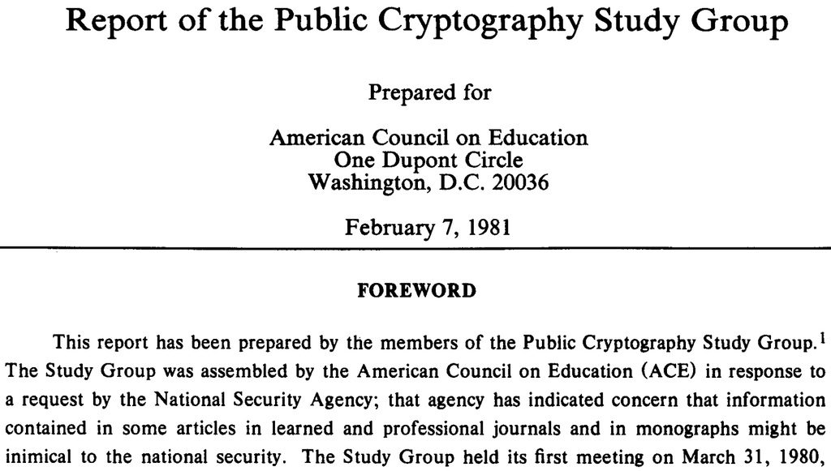

[Report of the Public Cryptography Study Group](https://dl.acm.org/doi/pdf/10.1145/358699.358710)

### Export controls

Even after *Bernstein v. United States*, cryptography is still subject to some export restrictions by the:

- [International Traffic in Arms Regulations](https://en.wikipedia.org/wiki/International_Traffic_in_Arms_Regulations), which directly cover military equipment, and
- [Export Administration Regulations](https://en.wikipedia.org/wiki/Export_Administration_Regulations), which broadly cover technology that can be used by the military

Export controls are a real thing, and people occasionally are imprisoned for it. They are also broad: technically, this very lecture constitutes an ‘export’ of crypto knowledge.

Both ITAR and EAR exempt **fundamental research** from export controls, as long as it is:

- Published and shared broadly with the scientific community
- Not subject to any restrictions on what can be published

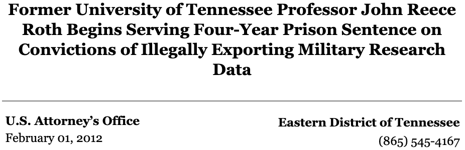

image source: fbi.gov

Remember, this is not legal advice! If you find yourself in a situation where you need actual legal advice, talk to the [BU/MIT Student Innovations Law Clinic](https://www.bu.edu/law/experiential-learning/clinics/bu-mit-student-innovations-law-clinic/).

## 25.3 Crypto and Intellectual Property

The [U.S. Constitution](https://www.archives.gov/founding-docs/constitution-transcript) itself says that:

> The Congress shall have Power … To promote the Progress of Science and useful Arts, by securing for limited Times to Authors and Inventors the exclusive Right to their respective Writings and Discoveries

> – United States Constitution, Article I, Section 8, Clause 8

**Interactive question.** This sentence essentially refers to intellectual property. Where do you think that cryptography most connects to IP law?

1. *Copyrights*, which protect creative expressions (like books)
2. *Patents*, which protect scientific inventions (like the light bulb)
3. *Trademarks*, which protect brand names (like Coca-Cola®)
4. *Trade secrets*, which protect confidential business data (like the the Coca-Cola formula)

The answer, perhaps surprisingly, is *copyright law*.

- Cryptographers tend to [avoid patents](https://csrc.nist.gov/news/1997/requesting-candidate-algorithm-nominations-for-aes) since crypto only works if it is universally available
- Cryptographers avoid trade secrets due to Kerckhoffs’s principle

### Anti-circumvention

One use of encryption today is to stop piracy using Digital Rights Management (DRM) and anti-cheat software. Unlike all of the scenarios we have discussed in this course:

- DRM software is running on your computer, and yet
- From the perspective of the song, movie, or video game studio: *you* are Mallory

The Digital Millenium Copyright Act says that: “No person shall circumvent a technological measure that effectively controls access to a [copyrighted] work.”

- A *technological measure*, for our purposes, means encryption
- The DMCA states that:

  > a technological measure “effectively controls access to a work” if the measure, in the ordinary course of its operation, requires the application of information, or a process or a treatment, with the authority of the copyright owner, to gain access to the work
- The DMCA also defines that:

  > to “circumvent a technological measure” means to descramble a scrambled work, to decrypt an encrypted work, or otherwise to avoid, bypass, remove, deactivate, or impair a technological measure, without the authority of the copyright owner

Essentially, the DMCA says that you can be liable if you use your cryptographic knowledge to break the encryption that is used to prevent copying of copyrighted data… even if that encryption is not good.

- Example: the crypto used in the Playstation 3 used ECDSA but suffered from [reused randomness](https://deeprnd.medium.com/decoding-the-playstation-3-hack-unraveling-the-ecdsa-random-generator-flaw-e9074a51b831). Even so, [Sony sued the person who publicized this bug](https://www.wired.com/2011/04/sony-settles-ps3-lawsuit/) under the DMCA.
- The DMCA exempts “security testing,” if you have the permission of the system designer.
- Nowadays, the Library of Congress allows an exception for any “[good-faith security research](https://www.copyright.gov/1201/2024/2024_Section_1201_Registers_Recommendation.pdf).” But this exception only applies for 3 years, and the Library of Congress can decide not to renew it.
- For this reason, Prof. Matt Green and the EFF are [currently suing](https://www.eff.org/cases/green-v-us-department-justice) the U.S. Department of Justice to argue that anti-circumvention law infringes on his First Amendment rights as a cryptanalyst.

### Computer Fraud and Abuse Act

Regardless of whether you obtain permission of the designer of a cryptographic *algorithm*, you must **always, always, always** obtain permission of the owner of any *device* that you study.

The [CFAA](https://www.law.cornell.edu/uscode/text/18/1030) is the law in the United States that governs hacking. It makes the following (and more) a crime:

> - intentionally accesses a computer **without authorization or exceeds authorized access**, and thereby obtains… information from any protected computer
> - knowingly and with intent to defraud, accesses a protected computer **without authorization, or exceeds authorized access**, and by means of such conduct … obtains anything of value
> - intentionally accesses a protected computer **without authorization**, and as a result of such conduct, causes damage and loss

The CFAA defines a “protected computer” to include any computer used in interstate or foreign commerce… which nowadays can be applied to every computer run by any company in the world.

Do not use other people’s computers without their authorization!

If you ever find yourself in a situation where you believe you might have violated the provisions of the CFAA, stop everything and immediately go to the [BU/MIT Student Innovations Law Clinic](https://www.bu.edu/law/experiential-learning/clinics/bu-mit-student-innovations-law-clinic/)!

## 25.4 Crypto and the Fourth Amendment

The Fourth Amendment to the U.S. Constitution says:

> The right of the people to be secure in their persons, houses, papers, and effects, against unreasonable searches and seizures, shall not be violated, and no Warrants shall issue, but upon probable cause, supported by Oath or affirmation, and particularly describing the place to be searched, and the persons or things to be seized.

Essentially, the Fourth Amendment constrains government *surveillance*. But note that it does not *prohibit* surveillance entirely.

**Interactive question.** Which of these scenarios most directly involves cryptography and the Fourth Amendment?

1. The government compels a technology company to change the crypto algorithm that it uses
2. The government compels a technology company to provide the keys used in client-server crypto
3. The government compels you to provide the keys used in end-to-end crypto
4. The government compels you not to use modern, strong crypto

### Legal constraints on crypto

Let’s focus on the obligations of technology companies to respond to law enforcement.

In the United States, the [Electronic Communications Privacy Act](https://en.wikipedia.org/wiki/Electronic_Communications_Privacy_Act) imposes different requirements on different types of data.

- Providing real-time surveillance of content (like a phone wiretap) requires a strong “super warrant”
- Providing real-time surveillance of metadata (who is talking to whom) only requires a subpoena where the government attests that the information it will obtain is “relevant” to a case
- Access to stored content on a hard drive is generally similar: accessing content requires a warrant but metadata does not

But even if the government obtains a legal warrant, is the data even accessible to them?

- For telecommunication companies specifically, the 1994 [Communications Assistance for Law Enforcement Act](https://en.wikipedia.org/wiki/Communications_Assistance_for_Law_Enforcement_Act) requires that any crypto built by telecommunication companies must make it possible for the government to perform targeted wiretapping
- Technology companies are generally not subject to CALEA, and typically can offer end-to-end encryption… but if they *choose* to use client-server crypto and hold onto cryptographic keys, then they can be subject to warrants + subpoenas to provide these keys to the government

In other words:

- WhatsApp or iCloud can use end-to-end encryption, even for voice and video calls
- But telephone calls (that go through AT&T, T-Mobile, Verizon, etc) cannot

This is why the newest wave of the “crypto wars” is by governments attempting to stop end-to-end encryption, instead preferring client-server encryption with long-term keys that they can fetch from the server with a warrant or subpoena.

### Legal incentives to use good crypto

There is one word that is often associated with the Fourth Amendment but conspicuously absent from its text: **privacy**. Let’s move away from the Fourth Amendment and talk about privacy law.

The law provides some incentives to use good cryptography.

- Using its power to regulate commerce, Congress has passed laws to protect data in domains like [healthcare](https://www.hhs.gov/hipaa/index.html) , [education](https://studentprivacy.ed.gov/ferpa), and [finance](https://www.ftc.gov/business-guidance/privacy-security/gramm-leach-bliley-act). These laws tend to [promote strong incentives](https://www.hhs.gov/hipaa/for-professionals/faq/2001/is-the-use-of-encryption-mandatory-in-the-security-rule/index.html) to use encryption to protect data at rest and in use.
- If a company suffers from a data breach, their liability can depend on whether their data security practices were “[reasonable](https://www.cisecurity.org/insights/white-papers/reasonable-cybersecurity-guide).” Following established [best practices](https://www.lawinsider.com/dictionary/best-practice) like using strong encryption is important to defend one’s actions as reasonable.
- If (when?) a company violates its own stated privacy policies or misrepresents its products in a deceptive way, the [U.S. Federal Trade Commission](https://www.ftc.gov/) can sue the company, and this often results in the company agreeing to a Consent Order and promising to follow good information security practices.

**Example.** Zoom previously misrepresented its encryption scheme as end-to-end encrypted, when it was not. Now they show the difference clearly, and have agreed to follow this [consent order](https://www.ftc.gov/system/files/documents/cases/1923167zoomacco2.pdf).

[figure not shown]

End-to-end encrypted

[figure not shown]

Not end-to-end encrypted

## 25.5 Crypto and the Fifth Amendment

The Fifth Amendment to the U.S. Constitution says, in part:

> No person… shall be compelled in any criminal case to be a witness against himself, nor be deprived of life, liberty, or property, without due process of law

**Question.** Can the police compel you to enter the password to unlock (and decrypt) the contents of your laptop or phone?

- More than 100 countries provide some form of a [right to silence](https://en.wikipedia.org/wiki/Right_to_silence)
- The United States has a right against self-incrimination, which is slightly different…

The privilege against self-incrimination only applies to acts that are:

- *Compelled*, so it does not apply if you [voluntarily talk to the police](https://www.youtube.com/watch?v=d-7o9xYp7eE)
- *Incriminating* (which is almost always possible)
- *Testimonial*, meaning that it relates to the contents of your mind

Since entering a passcode uses your mind, let’s delve deeper into the idea of “testimony.” Based on the 1977 court case [Fisher v. United States](https://supreme.justia.com/cases/federal/us/425/391/), testimony covers:

- *Direct testimony*, like written and oral statements
- *Indirect testimony*, where “compliance with the subpoena tacitly concedes [your] belief”
- …but not if the indirect testimony is a *foregone conclusion*, meaning that the government already knows the testimonial information

With this legal background, let’s return to the question.

**Question.** Can the police compel you to enter the password to unlock (and decrypt) the contents of your laptop or phone?

Don’t feel bad if you have no idea what the answer to this question should be. Turns out: nobody else knows either.

> “whether the privilege bars compelled entry of the password (as opposed to its disclosure) depends on a choice of analogy”

> – Prof. Orin Kerr (UC Berkeley Law), [Harvard Law Review, 2021](https://harvardlawreview.org/print/vol-134/decryption-originalism-the-lessons-of-burr/)

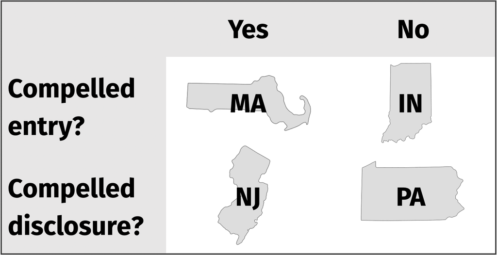

I personally hate this state of affairs, so my collaborators and I explored it in more detail. First, we looked at the paragraph in which the Supreme Court defines foregone conclusions (emphasis added by me):

> Surely the Government is in no way **relying on the “truthtelling”** of the [defendant] to prove the existence of or his access to the documents. The existence and location of the papers are a foregone conclusion, and the [defendant] **adds little or nothing to the sum total of the Government’s information** by conceding that he, in fact, has the papers.

> – U.S. Supreme Court, [decision](https://supreme.justia.com/cases/federal/us/425/391/) in Fisher v. United States (1977)

Our belief is that the Supreme Court’s ideas actually match very well to crypto-style definitions!

- We precisely defined the idea of “not adding information” as a *cryptographic simulator* in ZK proofs
- We precisely defined the idea of “not relying on the truthtelling” in EU-CMA, pseudorandomness, and authenticated encryption with the notion of Mallory being spun around in a room and not knowing which direction has the truth vs the lie

So, we wrote two [research](https://eprint.iacr.org/2020/862.pdf) [papers](https://arxiv.org/pdf/2208.02905) to argue about encryption and the foregone conclusion doctrine directly, without the need to go through analogies.

In conclusion:

- The law has a lot of influence over how cryptography is used, in both good and bad ways
- But maybe crypto also has something to say about how to interpret the law?

## Thanks!

I hope you have enjoyed taking this course as much as Julie and I have enjoyed teaching it. We look forward to seeing all of the things you build with your knowledge of cryptography and data security!

Remember that the Final Exam is next Friday 12/19.